# Laboratory Data Survival Analysis

## Lab Data Set Analysis

### Introduction

In an attempt to associate physiological measurements to the development of diabetes, we decided to include the NHANES Laboratory Dataset which were a part of the main NHANES data source. The Laboratory Dataset included more than 40 different physiological tests which resulted in 13,000+ rows and 338 features. Additionally, we left merged with the diabetes dataset to include the event and time-to-event which added 2 more features resulting in 340 features in the final survival analysis dataset.

To investigate the most notable features that have the most significant impact in the development of diabetes, we fitted multiple Cox Proportional Hazards model for each feature from the merged laboratory dataset. We then took the most statistically significant and highly impactful features through given p-values and Hazard Ratios from the fitted Cox models. Finally, we generated Kaplan-Meier survival curves and annotated p-values associated to the relationships of the physiological features and survival time onto each plot.

### Data

The cleaned laboratory testing data is imported here and further cleaned. We noticed the diabetes dataset that we will use for our time and event included numerous rows of empty values which we replaced with NA here. Additionally, for the sake of cleanliness and efficiency we have decided to replace “yes” and “borderline” values of being diagnosed with type II diabetes to 1 with other values being replaced with 0. Finally, to utilize the diabetes data with our laboratory data we left merged the diabetes dataset with the cleaned laboratory dataset.

### Find Most Impactful/Significant Features with Cox Model

With more than 300 features in the laboratory data, we decided to sift through them all by fitting univariate Cox Proportional Hazard models on each feature. This will find all features that provide significant impact in time to event. More specifically, we will save the p-value and hazard ratio of each Cox model to a data frame which helps describe the impact of each feature on time-to-event. We then take the top features with the highest statistical significance (lowest p-values) and strongest impact (highest absolute HR values) on the event to do survival analysis.

### Find the Features with the Lowest P-values

| Feature | p_value | hazard_ratio |
| --- | --- | --- |
| LBXGH | 0.000000e+00 | 1.6441293 |
| LBDGLUSI | 9.210755e-189 | 1.2482920 |
| LBXGLU | 9.607386e-189 | 1.0123876 |
| LBDHDD | 2.756016e-46 | 0.9684911 |
| LBDHDDSI | 2.884411e-46 | 0.2898961 |
| LBDTCSI | 9.109605e-43 | 0.6742733 |
| LBXTC | 9.436389e-43 | 0.9898618 |
| URDACT | 6.849226e-37 | 1.0003217 |
| LBDINSI | 1.897108e-33 | 1.0011989 |
| LBXIN | 1.897108e-33 | 1.0072152 |

**Get the top Features based on lowest p-values.**

### Find the Features with Largest HR Values

After taking the top 100 features based on p-values, we take a look at the top features with the highest absolute hazard ratio values.

| Feature | p_value | hazard_ratio |
| --- | --- | --- |
| LBXVMIK | 2.108761e-04 | 1.912908e+08 |
| URDNO3LC | 1.228403e-07 | 2.178946e+01 |
| LBDBANO | 7.226575e-07 | 1.413086e+01 |
| SSAGP | 6.101526e-05 | 4.662637e+00 |
| LBDNFOSL | 9.408361e-04 | 4.447291e+00 |
| LBDNFOAL | 2.425506e-03 | 3.920440e+00 |
| LBDMFOSL | 3.982923e-04 | 2.960122e+00 |
| SSIPPP | 1.038603e-02 | 2.826826e+00 |
| LBDPFHSL | 6.792054e-03 | 2.636349e+00 |
| URDUBALC | 9.110908e-03 | 2.305594e+00 |

**Get the top features with the highest HR values.**

**Observations:**

It seems the top 3 features ‘LBXVMIK’, ‘URDNO3LC’, and ‘LBDBANO’ offer the most impact in the univariate cox model for diabetes.

The top 3 features are:

- ‘LBXVMIK’ is **Blood Methyl Isobutyl Ketone (ng/mL)**
- ‘URDNO3LC’ is **Nitrate, urine Comment Code**
- ‘LBDBANO’ is **Basophils number (1000 cell/uL)**

The top features found were the highest Hazard Ratio magnitudes found from most significant features. One of the features found was the Nitrate urine comment code which we feel could be removed as it doesn’t actually inform us about the physiological feature. The comment code describes if there were any issues during the measurement data collection step. Thus, we will overlook this features and move forward with the other 2 top features for Blood Methyl Isobutyl Ketone and Basophils number.

### Diabetes Survival Curve Stratified by LBXVMIK

‘LBXVMIK’ is **Blood Methyl Isobutyl Ketone (ng/mL)**

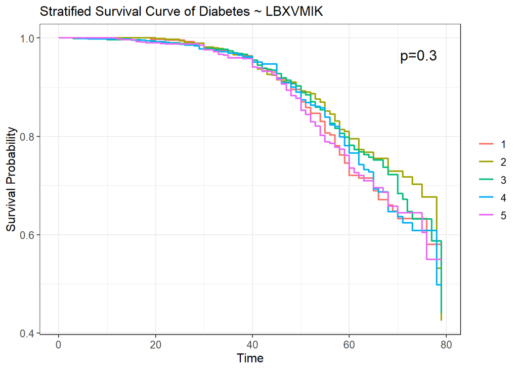

### Diabetes Survival Curve Stratified by LBDBANO

‘LBDBANO’ is **Basophils number (1000 cell/uL)**

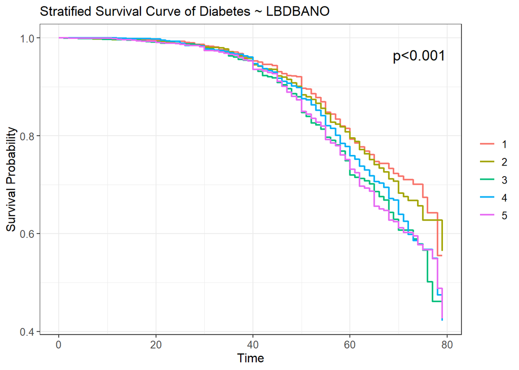

## Conclusions

From the Kaplan-Meier survival curves done above, only **LBDBANO** or **Basophils number (1000 cell/uL)** showed statistically significant difference in the survival analysis between basophils number ranges.

Basophils are a type of white blood cell and play a key role in protecting the body from infections, cancer cells, parasites, fungi, and allergens. They are produced in the bone marrow and circulate in the bloodstream for a period of time before entering tissues.

There was an article about the affects of white blood cell count in inducing type 2 Diabetes. The paper investigates epidemiology studies and found that a raised white blood cell count is associated with a higher risk of type 2 Diabetes. Though it prefaces that there could be publication bias and also a failure to control for all potential confounding factors[^1].

## Footnotes

[^1]: https://pmc.ncbi.nlm.nih.gov/articles/PMC2956635/